# Make signature network and train top scoring pair classifier

This is a part that we found was conceptually tricky for a lot of the folks we talked to. With the samples all classified, now we can check how often a given sample is assigned to each of the classes. Then, we can check how similar the class assignment profile of a given tumor is to every other tumor. This similarity in the assignment of tumors to classes is the root of the network: when lots of tumors are assigned to the same two classes, those two classes are highly connected in the network – and then we scale that to all the classes.

Then we cluster the network. That means we ask whether some nodes are more connected to each other than you’d expect from considering the network as a whole. This clustering step is how we find that many classes are effectively very similar: while the geneset in the classifier might be quite different, effectively they are acting on a very similar underlying signal and the same tumors are assigned to the same classes.

Finally, we want to use this clustering of classes to train a classifier (ie given a single sample, which cluster of classes would it be assigned to?). We chose a top scoring pair (TSP) algorithm here because it is very flexible: the assignment is made from the relative expression at pairs of genes, which means the absolute values are a lot less important, making the algorithm very portable among platforms. We train the TSP on only the samples where all the classifiers agree on the cluster class.

## Filter out classifiers with low assignment rates

We started with all the BTC RNA tumour classifiers we could find. This meant some didn’t fit well with our data. As a first step, we removed classifiers where very few of our samples could be conclusively (FDR < 0.05) classified into any class.

```r
suppressPackageStartupMessages({
  library(data.table)
  library(dplyr)
  library(tidyr)
  library(stringr)
  library(Matrix)
  library(MCL)
  library(switchBox)
  library(DescTools)
  library(cluster)
  library(ggplot2)
  library(ggraph)
  library(ggrepel)
  library(ggforce)
  library(PNWColors)
  library(tidygraph)
  library(igraph)
  library(cowplot)
})

packageVersion('switchBox')
```

```
## [1] '1.48.0'
```

```r
packageVersion('MCL')
```

```
## [1] '1.0'
```

```r
set.seed(123)

code.dir = '~/Documents/scripts/github/btc-ccs/'
data.dir = '~/Documents/scripts/github/btc-ccs-data/'

source( file.path(code.dir, "bin/BTC.functions.R"))
source( file.path(code.dir, "bin/network.functions.R"))


labels_df.raw <- fread(file.path(data.dir,"/results/classified.FF.txt"))

labels_df.raw <- labels_df.raw  %>% dplyr::select( -starts_with("martinserrano") )

classifieds.n <- tally_class_assignments(labels_df.raw)
```

```
## processing 126 samples across 24 classes from 9 classifiers.
```

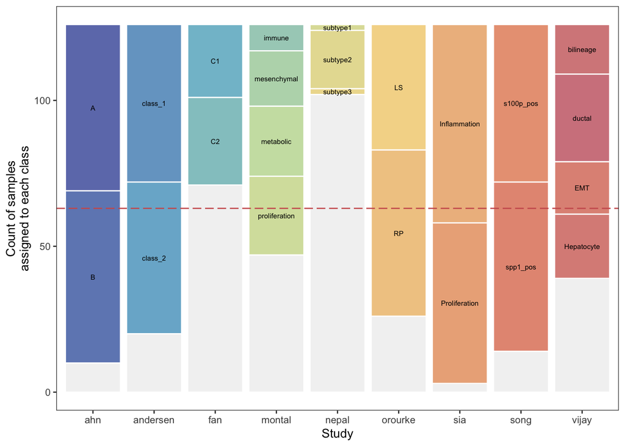

```r
sig.colors <- cbind.data.frame('class'=unique(classifieds.n$class),
                               'color'=c(pnw_palette(name="Sailboat", n=length(unique(classifieds.n$class)) ))
)

sig.colors.vec <- sig.colors$color
names(sig.colors.vec) <- sig.colors$class

signature_dropout.plot <-
ggplot(classifieds.n , aes(x=variable, y=n, fill=class )) +
  geom_bar(stat='identity', color='white') +

  geom_hline(yintercept = nrow(labels_df.raw)/2, color='indianred',linetype='longdash') +

  geom_text(stat='identity',aes(label=value),size=2,
            position = position_stack(vjust = 0.5)
  ) +
  theme_bw(base_size=10) +
  scale_fill_manual(values =  sig.colors.vec, na.value = 'grey95') +
  theme(panel.grid = element_blank(), plot.background = element_blank(),
        panel.background = element_blank()) +
  guides(fill='none') + labs(x='Study',y='Count of samples\nassigned to each class')

signature_dropout.plot
```

```r
ggsave(paste0(data.dir, "/results/fig/FIGS2A.signature_dropout.svg"), plot =
  signature_dropout.plot
, device = "svg", height = 70,width = 125, units = 'mm' )
labels_df <- remove_unassigned_classifiers(labels_df.raw, classifieds.n)
```

```
## removing 2 classifiers for low assignment rates: fan, nepal
```

```
## 7 classifiers remain.
```

## Make matrix

Here, we start making the similarity matrix for the network. We loop through classes and calculate the Jaccard similarity in assignments.

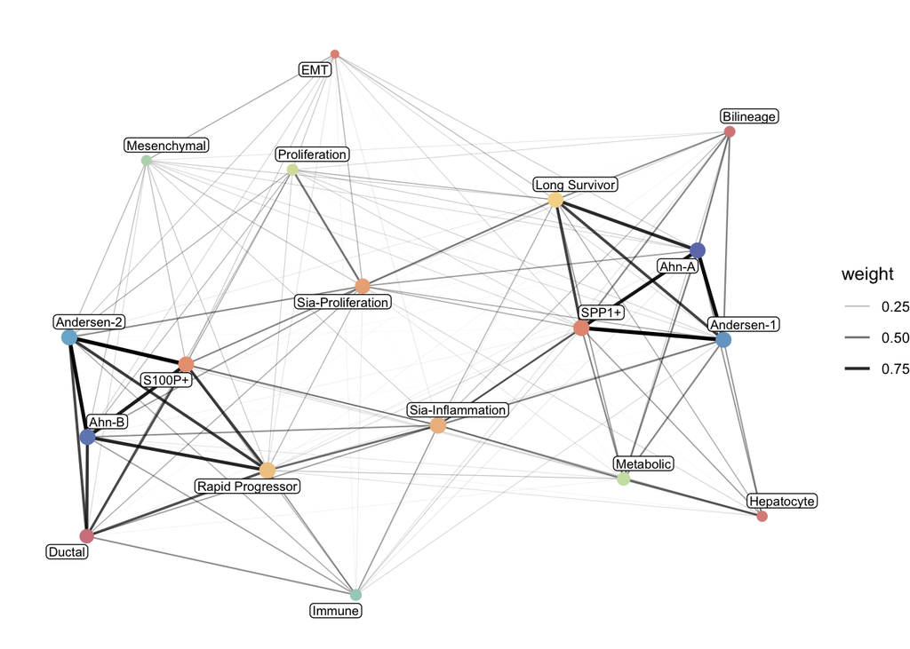

```r
adj <- make_adjacency_matrix(labels_df)

g <- graph_from_adjacency_matrix(adj, mode = "undirected", weighted = TRUE)

tg <- as_tbl_graph(g)

tg <- tg %>%
  mutate(paper = paper_sources[name])

tg <- tg %>%
  mutate(short_name = short_name_key[name])

subtype_counts <-
  subtype_counts <- labels_df %>%
  pivot_longer(cols = -Sample, names_to = "System", values_to = "Subtype") %>%
  mutate(Node = paste0(System, "_", Subtype)) %>%
  group_by(Node) %>%
  summarise(sample_count = n(), .groups = "drop")

tg <- tg %>%
  left_join(subtype_counts, by = c("name" = "Node"))

layout <- create_layout(tg, layout = "fr")

full_signature_network.plot <-
           ggraph(layout) +
           geom_edge_link(aes(width = weight, alpha=weight), color = "black") +
           geom_node_point(aes(x = x, y = y, color = name, size = sample_count), shape = 16) +
           geom_node_label(aes(x = x, y = y, label = short_name), repel = TRUE, size = 2.5 , label.padding = 0.1) +

           scale_edge_width(range = c(0.01, 1)) +
             scale_color_manual(values =  sig.colors.vec )+

           scale_size_continuous(range = c(2, 4))  +

           theme_void(base_size = 10) +
           theme(legend.position = "right"  )  +
         guides(color='none',size='none')+
           scale_x_continuous(expand = expansion(mult = 0.1)) +
           scale_y_continuous(expand = expansion(mult = 0.1))

full_signature_network.plot
```

```r
ggsave(paste0(data.dir, "/results/fig/FIGS2b.full_signature_network.svg"), plot =
          full_signature_network.plot
  , device = "svg", height = 70,width = 95, units = 'mm' )
```

## Filter for well connected nodes (classes)

We first drop classes where the class is connected to less than 2% of the network. We then loop across inflation factors to optimize the network and iteratively dropping classes that do not belong to a cluster.

```r
adj_filtered <- remove_disconnected_classes(labels_df, adj)
```

```
## dropping 4 class for low connectivity: montal_mesenchymal, montal_immune, vijay_Hepatocyte, vijay_EMT
```

```r
#### optimize

inflation.res <- explore_optimization_space(adj_filtered)
```

```
##
## ---------------
## Running MCL with inflation = 1.5
```

```
## Only one cluster.
```

```
##
## ---------------
## Running MCL with inflation = 2
```

```
##
## ---------------
## Running MCL with inflation = 2.5
```

```
##
## ---------------
## Running MCL with inflation = 3
```

```
##
## ---------------
## Running MCL with inflation = 3.5
```

```
##
## ---------------
## Running MCL with inflation = 4
```

```
##
## ---------------
## Running MCL with inflation = 4.5
```

```
##
## Some signatures have no class.
```

```
## Dropping 1...
```

```
##
## ---------------
## Running MCL with inflation = 5
```

```
##
## Some signatures have no class.
```

```
## Dropping 1...
```

```
##
## ---------------
## Running MCL with inflation = 5.5
```

```
##
## Some signatures have no class.
```

```
## Dropping 1...
```

```
##
## ---------------
## Running MCL with inflation = 6
```

```
##
## Some signatures have no class.
```

```
## Dropping 1...
```

```
##
## ---------------
## Running MCL with inflation = 6.5
```

```
##
## Some signatures have no class.
```

```
## Dropping 2...
```

```
##
## ---------------
## Running MCL with inflation = 7
```

```
##
## Some signatures have no class.
```

```
## Dropping 2...
```

```
##
## ---------------
## Running MCL with inflation = 7.5
```

```
##
## Some signatures have no class.
```

```
## Dropping 2...
```

```
##
## ---------------
## Running MCL with inflation = 8
```

```
##
## Some signatures have no class.
```

```
## Dropping 3...
```

```
##
## ---------------
## Running MCL with inflation = 8.5
```

```
##
## Some signatures have no class.
```

```
## Dropping 3...
```

```
##
## ---------------
## Running MCL with inflation = 9
```

```
##
## Some signatures have no class.
```

```
## Dropping 3...
```

```
##
## ---------------
## Running MCL with inflation = 9.5
```

```
##
## Some signatures have no class.
```

```
## Dropping 3...
```

```
##
## ---------------
## Running MCL with inflation = 10
```

```
##
## Some signatures have no class.
```

```
## Dropping 3...
```

```
##
## ---------------
## Running MCL with inflation = 10.5
```

```
##
## Some signatures have no class.
```

```
## Dropping 3...
```

```
##
## ---------------
## Running MCL with inflation = 11
```

```
##
## Some signatures have no class.
```

```
## Dropping 3...
```

```
##
## ---------------
## Running MCL with inflation = 11.5
```

```
##
## Some signatures have no class.
```

```
## Dropping 3...
```

```
##
## ---------------
## Running MCL with inflation = 12
```

```
##
## Some signatures have no class.
```

```
## Dropping 3...
```

```
##
## ---------------
## Running MCL with inflation = 12.5
```

```
##
## Some signatures have no class.
```

```
## Dropping 3...
```

```
##
## ---------------
## Running MCL with inflation = 13
```

```
##
## Some signatures have no class.
```

```
## Dropping 3...
```

```
##
## ---------------
## Running MCL with inflation = 13.5
```

```
##
## Some signatures have no class.
```

```
## Dropping 3...
```

```
##
## ---------------
## Running MCL with inflation = 14
```

```
##
## Some signatures have no class.
```

```
## Dropping 3...
```

```
##
## ---------------
## Running MCL with inflation = 14.5
```

```
##
## Some signatures have no class.
```

```
## Dropping 3...
```

```
##
## ---------------
## Running MCL with inflation = 15
```

```
##
## Some signatures have no class.
```

```
## Dropping 3...
```

```
##
## ---------------
## Running MCL with inflation = 15.5
```

```
##
## Some signatures have no class.
```

```
## Dropping 3...
```

```
##
## ---------------
## Running MCL with inflation = 16
```

```
##
## Some signatures have no class.
```

```
## Dropping 3...
```

```
##
## ---------------
## Running MCL with inflation = 16.5
```

```
##
## Some signatures have no class.
```

```
## Dropping 3...
```

```
##
## ---------------
## Running MCL with inflation = 17
```

```
##
## Some signatures have no class.
```

```
## Dropping 3...
```

```
##
## ---------------
## Running MCL with inflation = 17.5
```

```
##
## Some signatures have no class.
```

```
## Dropping 3...
```

```
##
## ---------------
## Running MCL with inflation = 18
```

```
##
## Some signatures have no class.
```

```
## Dropping 3...
```

```
##
## ---------------
## Running MCL with inflation = 18.5
```

```
##
## Some signatures have no class.
```

```
## Dropping 3...
```

```
##
## ---------------
## Running MCL with inflation = 19
```

```
##
## Some signatures have no class.
```

```
## Dropping 3...
```

```
##
## ---------------
## Running MCL with inflation = 19.5
```

```
##
## Some signatures have no class.
```

```
## Dropping 3...
```

```
##
## ---------------
## Running MCL with inflation = 20
```

```
##
## Some signatures have no class.
```

```
## Dropping 3...
```

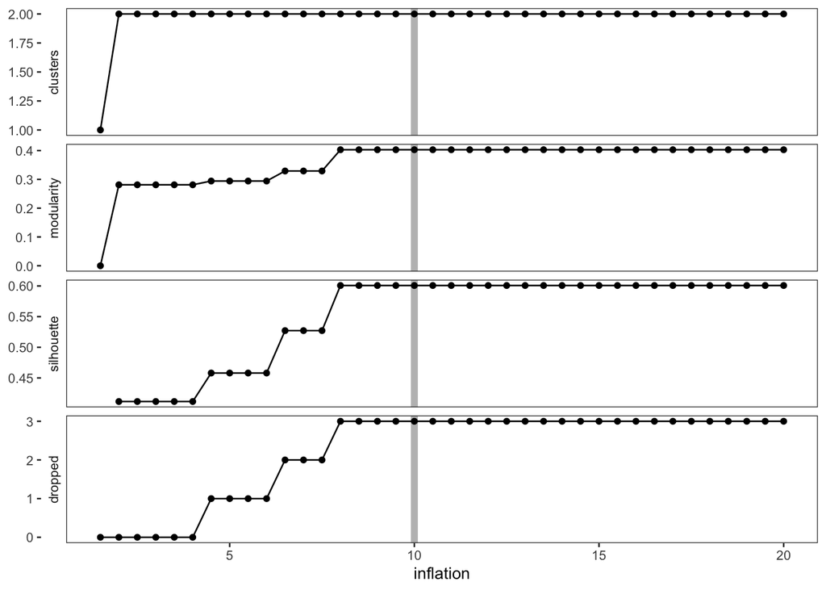

```r
final.inflation <- as.numeric(inflation.res['inflation'])

ggsave(paste0(data.dir, "/results/fig/FIGS2C.network_optimization.svg"), plot =
         inflation.res['inflation.plot']
, device = "svg", height = 70,width = 90, units = 'mm' )
final.adj_classed <- filter_for_inflation(adj_filtered, final.inflation)
```

```
## dropping 3 classes after inflation adjustment: sia_Proliferation, sia_Inflammation, montal_proliferation
```

```
## 11 classes remain: andersen_class_2, andersen_class_1, song_s100p_pos, song_spp1_pos, montal_metabolic, vijay_ductal, vijay_bilineage, orourke_RP, orourke_LS, ahn_B, ahn_A
```

## Visualize final graph

```r
final.membership <- assign_classes_to_clusters(final.adj_classed, final.inflation)
print(final.membership)
```

```
## andersen_class_2 andersen_class_1   song_s100p_pos    song_spp1_pos
##                2                1                2                1
## montal_metabolic     vijay_ductal  vijay_bilineage       orourke_RP
##                1                2                1                2
##       orourke_LS            ahn_B            ahn_A
##                1                2                1
```

```r
## graph stats

cluster_ids <- unique(final.membership)
set_A <- which(final.membership == cluster_ids[1])
set_B <- which(final.membership == cluster_ids[2])

observed <- sum(final.adj_classed[set_A, set_B] > 0)

num_nodes <- nrow(final.adj_classed)
N <- choose(num_nodes, 2)
K <- length(set_A) * (num_nodes - length(set_A))
n <- length(set_B) * (num_nodes - length(set_B))

hypergeometic.test.res <- signif(phyper(observed - 1, K, N - K, n, lower.tail = FALSE),2)

message('significantly interconnected clusters of classes (p = ',hypergeometic.test.res)
```

```
## significantly interconnected clusters of classes (p = 2.6e-06
```

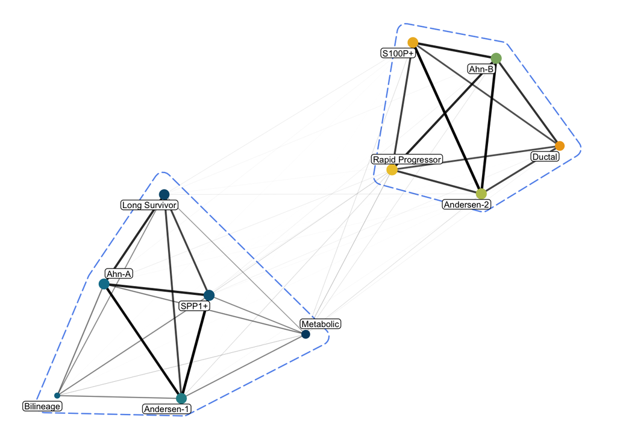

```r
## view graph

final.g_classed <-
  graph_from_adjacency_matrix(final.adj_classed, mode = "undirected", weighted = TRUE)

tg <- as_tbl_graph(final.g_classed) %>%
  mutate(cluster = as.factor(final.membership[name]))

tg <- tg %>%
  mutate(paper = paper_sources[name])
tg <- tg %>%
  mutate(short_name = short_name_key[name])

subtype_counts <-
  subtype_counts <- labels_df %>%
  pivot_longer(cols = -Sample, names_to = "System", values_to = "Subtype") %>%
  mutate(Node = paste0(System, "_", Subtype)) %>%
  group_by(Node) %>%
  summarise(sample_count = n(), .groups = "drop")

tg <- tg %>%
  left_join(subtype_counts, by = c("name" = "Node"))

replot_network = F
if(replot_network){ num.plots = 20 } else { num.plots = 1}

for(i in c(1:num.plots)){
  layout <- create_layout(tg, layout = "fr")

  signature_network.plot <-
    ggraph(layout) +
      # Draw convex hulls around clusters
      geom_mark_hull(aes(x = x, y = y, group = cluster),
                     concavity = 3,  color = "cornflowerblue", linetype='longdash', size=0.5, ) +
      # Draw edges
      geom_edge_link(aes(width = weight, alpha=weight), color = "black", show.legend = FALSE) +
      # Draw nodes
      geom_node_point(aes(x = x, y = y, color = short_name, size = sample_count), shape = 16) +
      # Add labels
      geom_node_label(aes(x = x, y = y, label = short_name), repel = TRUE, size = 2.5 , label.padding = 0.1) +

      scale_edge_width(range = c(0.01, 1)) +


      scale_color_manual(values = c(
        'Immune' = pnw_palette(name="Bay", n=19 )[c(10)],
        'Metabolic' = pnw_palette(name="Bay", n=19 )[c(1)],

        'Ahn-A'  =pnw_palette(name="Bay", n=19)[c(5)]      ,
        'Ahn-B' =pnw_palette(name="Bay", n=19)[c(8)] ,

        'Long Survivor' = pnw_palette(name="Bay", n=19 )[c(2)],
        'Rapid Progressor' =pnw_palette(name="Bay", n=19 )[c(11)] ,

        'Ductal' = pnw_palette(name="Bay", n=19 )[c(13)],
        'Bilineage' = pnw_palette(name="Bay", n=19 )[c(4)],

        'S100P+' =pnw_palette(name="Bay", n=19 )[c(12)],
        'SPP1+' =pnw_palette(name="Bay", n=19 )[c(3)],

        'Andersen-2' = pnw_palette(name="Bay", n=19 )[c(9)],
        'Andersen-1' = pnw_palette(name="Bay", n=19 )[c(6)]

      )) +
      scale_size_continuous(range = c(2, 4))  +
      guides(width='none',
             color='none',
             size='none'
             ) +
      theme_void(base_size = 10) +
      theme(plot.margin = unit(c(2, 2, 2, 2), "mm"),
            legend.position = "right"  )  +
      scale_x_continuous(expand = expansion(mult = 0.1)) +
      scale_y_continuous(expand = expansion(mult = 0.1))+ coord_cartesian(clip = "off")

  if(replot_network){
    ggsave(paste0(data.dir, "/results/fig/FIG2A.signature_network.run_",i,".svg"), plot =
    signature_network.plot
    , device = "svg", height = 40,width = 100, units = 'mm', dpi=72 )

  } else {
    print(signature_network.plot)
  }

}
```

## make consensus cohort

This is the set of samples where all (remaining) classifiers assign the sample to the same class cluster. We remove classifiers where more than 20% of samples are unassigned in remaining classes.

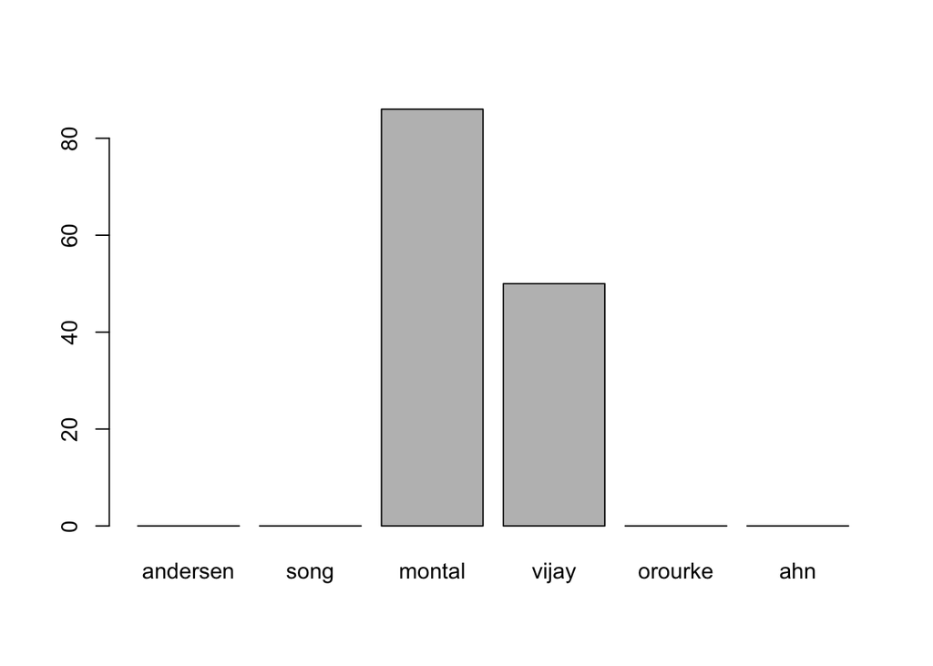

```r
dt <- assign_consensus_to_calls(labels_df, final.membership)

na_counts <- colSums(is.na(dt))
barplot(na_counts)
```

```r
cms_labels <- make_consensus_cohort(labels_df, dt)
```

```
## 99 samples were consistantly classified across all classes
```

```
## 27 samples were inconsistantly classified
```

## Train top scoring pair (TSP) algorithm

Train the TSP algorithm on 80% of the data from the TPM data.

```r
filtered_mat <- prep_expression_data(basedir = data.dir)

classifier <- train_tsp_on_consensus_cohort(filtered_mat, cms_labels, data.dir)
```

```
## full set has 99 samples
```

```
## training set has 79 samples
```

```
##          Actual
## Predicted  1  2
##         0 11  0
##         1  0  9
##      est    lwr.ci upr.ci
## [1,]   1 0.8388748      1
```

```r
tsp.genes <- data.frame(classifier$TSPs)
names(tsp.genes) <- c('CCS-A','CCS-B')

retrain_tsp = F
if(retrain_tsp){

  write.table( tsp.genes,
             file = file.path(data.dir,"/results/tsp.genes.txt"),
             row.names = F,col.names = T, quote = FALSE, sep = "\t", append =F)

  model.date <- format(Sys.time(), "%y%m%d")

  saveRDS(classifier, file.path(data.dir,"/results/tps.classifier.rds"))
  saveRDS(classifier, paste0(data.dir,'/results/tps.classifier.',model.date,'.rds'))


} else {

  classifier <- readRDS(file.path(data.dir,"/results/tps.classifier.rds"))

}
```

## Save CCS calls for all samples

```r
rna_raw <- fread(file.path(data.dir,"/results/rna.tpm.all.txt"))

rna_raw.mat <- as.matrix(rna_raw[,-1])
rownames(rna_raw.mat) <- rna_raw$gene_name

predicted.w.score <- predict_TSP_with_confidence(tsp_classifier=classifier,
                                                 tpm_matrix=rna_raw.mat,
                                                 confidence_cutoff = 10/16)

split_cols <-  data.frame(str_split_fixed(rownames(predicted.w.score), "_", 3))
predicted.w.score <- cbind.data.frame('BTC_ID'=paste(split_cols$X1, split_cols$X2, sep="_"),
                                      'Sample'=rownames(predicted.w.score),
                                      predicted.w.score)

write.table( predicted.w.score %>% dplyr::select(BTC_ID, Sample, rna_class, confidence.polarized) ,
             file = file.path(file.path(data.dir,"/results/all.eCCS.txt")), row.names = FALSE, quote = FALSE, sep = "\t")

##
samples.info <- fread(file.path(data.dir,"/results/samples.info.txt"))


write.table( rna_raw %>% dplyr::select(all_of(c('gene_name',samples.info$Sample[samples.info$rna]))) ,
             file = file.path(file.path(data.dir,"/results/tableS8A.tpm.txt")), row.names = FALSE, quote = FALSE, sep = "\t")

write.table( predicted.w.score %>%
               filter(Sample %in% samples.info$Sample) %>%
               dplyr::select(Sample, rna_class, confidence.polarized) ,
             file = file.path(file.path(data.dir,"/results/tableS8B.ccs.txt")), row.names = FALSE, quote = FALSE, sep = "\t")
```

## Make heatmap

This is just for visualization - take all the things we’ve develloped here and put them in one plot: stack the remaining classifiers, with the CCS class and then with the expression levels of the genes in the TSP algorithm.

```r
labels_df <- fread(file.path(data.dir,"/results/classified.FF.txt"))
names(labels_df)[1] <- "Sample"
labels_df <- labels_df %>% dplyr::select(starts_with("Sample") | ends_with('.class'))
names(labels_df) <- gsub('.class','', names(labels_df) )
btc.sigs <- labels_df %>% dplyr::select(-fan,  -sia , -nepal)

btc.sigs.melt <- btc.sigs %>% reshape2::melt(id.vars=c('Sample'))

btc.sigs.melt$value[btc.sigs.melt$value == 'LS'] <- 'Long Survivor'
btc.sigs.melt$value[btc.sigs.melt$value == 'RP'] <- 'Rapid Progressor'

btc.sigs.melt$value[btc.sigs.melt$value == 's100p_pos'] <- 'S100P+'
btc.sigs.melt$value[btc.sigs.melt$value == 'spp1_pos'] <- 'SPP1+'

classifier <- readRDS(file.path(data.dir,"/results/tps.classifier.rds"))

predicted.w.score <- fread(file.path(data.dir,"/results/all.eCCS.txt"))
BTC_clinical.tumours <- fread(file.path(data.dir,'/source_data/BTC_clinical.tumours.tsv'), header=T)
predicted.w.score.clinic <- left_join(predicted.w.score, BTC_clinical.tumours)
predicted.w.score <- predicted.w.score.clinic %>% filter(`Sample Source(FFPE, FF)` == 'FF')
nrow(predicted.w.score)
```

```
## [1] 163
```

```r
all.LBR.rna <- fread(file.path(data.dir,"/results/rna.tpm.ff.txt"))

tsp.LBR.rna <- all.LBR.rna %>% filter(gene_name %in% c(classifier$TSPs)) %>% melt()
tsp.LBR.rna$gene <- factor(tsp.LBR.rna$gene_name, levels=c(classifier$TSPs))

tsp.LBR.rna$log <- log(tsp.LBR.rna$value )
tsp.LBR.rna$log[!is.finite(tsp.LBR.rna$log)] <- NA
tsp.LBR.rna$tpm.scale <- scale(tsp.LBR.rna$log)

predicted.w.score$Samples <- factor(predicted.w.score$Sample, levels=predicted.w.score$Sample[order(predicted.w.score$confidence.polarized)])
btc.sigs.melt$samples <- factor(btc.sigs.melt$Sample, levels=predicted.w.score$Sample[order(predicted.w.score$confidence.polarized)])
tsp.LBR.rna$Samples <- factor(tsp.LBR.rna$variable, levels=predicted.w.score$Sample[order(predicted.w.score$confidence.polarized)])

these.samples <- intersect(intersect(unique(btc.sigs.melt$sample),
                           unique(tsp.LBR.rna$Samples)), unique(predicted.w.score$Samples))

length(these.samples)
```

```
## [1] 126
```

```r
this_theme <- theme(
  panel.background = element_blank(),
  plot.background = element_blank(),
  panel.grid.major.x = element_blank(),
  panel.grid.minor = element_blank(),
  legend.background = element_rect(color = NA,fill=NA),
  legend.box.background = element_rect(color = NA,fill=NA),

  axis.text.x =element_blank(),
  panel.grid = element_blank(),
  axis.title =element_blank(),
  axis.ticks.x =element_blank(),
  legend.title=element_blank(),
  plot.title = element_blank(),
  panel.border = element_blank(),
  legend.spacing = unit(0, 'cm'),)

split.size2 = -0.05
base.font.size = 10

my.plot <- plot_grid(

  ggplot(btc.sigs.melt %>% filter(samples %in% these.samples & variable == 'song'), aes(x=samples, y='Song et al.', fill=value)) +
    geom_tile()+ theme_bw(base_size=base.font.size)+this_theme+
    scale_fill_manual(values = pnw_palette(name="Bay", n=19 )[c(12,3)], na.value = 'white') +
    theme(legend.direction = "horizontal" )+
    guides(fill='none')

  , NULL,

  ggplot(btc.sigs.melt %>% filter(samples %in% these.samples & variable == 'orourke'), aes(x=samples, y='ORourke et al.', fill=value)) +
    geom_tile()+ theme_bw(base_size=base.font.size)+this_theme+
    scale_fill_manual(values = pnw_palette(name="Bay", n=19 )[c(2,11)], na.value = 'white') +
    theme(legend.direction = "horizontal")+
    guides(fill='none')

  ,NULL,

  ggplot(btc.sigs.melt %>% filter(samples %in% these.samples & variable == 'andersen'), aes(x=samples, y='Andersen et al.', fill=value)) +
    geom_tile()+ theme_bw(base_size=base.font.size)+this_theme+
    scale_fill_manual(values = pnw_palette(name="Bay", n=19 )[c(6,9)], na.value = 'white') +
    theme(legend.direction = "horizontal" )+
    guides(fill='none')

  , NULL,

  ggplot(btc.sigs.melt %>% filter(samples %in% these.samples & variable == 'ahn'), aes(x=samples, y='Ahn et al.', fill=value)) +
    geom_tile()+ theme_bw(base_size=base.font.size) + this_theme+
    scale_fill_manual(values = pnw_palette(name="Bay", n=19)[c(5,8)], na.value = 'white') +
    guides(legend.direction = "horizontal")+
    guides(fill='none')

  ,NULL,
  ggplot(btc.sigs.melt %>% filter(samples %in% these.samples & variable == 'vijay'), aes(x=samples, y='Vijay et al.', fill=value)) +
    geom_tile()+ theme_bw(base_size=base.font.size)+this_theme+
    scale_fill_manual(values = c(
      'ductal' = pnw_palette(name="Bay", n=19 )[c(13)],
        'bilineage' = pnw_palette(name="Bay", n=19 )[c(4)]), na.value = 'white') +
    theme(legend.direction = "horizontal" )+
    guides(fill='none')

  ,NULL,
    ggplot(btc.sigs.melt %>% filter(samples %in% these.samples & variable == 'montal'), aes(x=samples, y='Montal et al.', fill=value)) +
    geom_tile()+ theme_bw(base_size=base.font.size)+this_theme+

    scale_fill_manual(values = c('metabolic' = pnw_palette(name="Bay", n=19 )[c(1)]), na.value = 'white') +
    theme(legend.direction = "horizontal" )+
    guides(fill='none')

  ,NULL,
  ggplot(tsp.LBR.rna %>% filter(Samples %in% these.samples), aes(x=Samples, y=gene, fill=tpm.scale)) + geom_tile() +
    theme_bw(base_size=base.font.size)+this_theme+
    scale_fill_gradient2(
      low = "darkblue",
      mid = "white",
      high = "darkred",
      midpoint = 0 ,
      na.value =  "darkblue"
    ) + theme(axis.text.x = element_blank(),

              axis.text.y = element_text(size = 5,face = "italic"),
              axis.ticks.x = element_blank())+ labs(fill='z-score')
   # guides(fill='none')

  ,NULL,

  ggplot(predicted.w.score %>% filter(Samples %in% these.samples ), aes(x=Samples, y='CCS-TSP', fill=as.factor(rna_class))) +
    geom_tile()+
    #  geom_point(aes(size=confidence), shape=1)+
    theme_bw(base_size=base.font.size)+this_theme+
    scale_fill_manual(values = pnw_palette(name="Bay", n=30)[c(3,20)], na.value = 'grey75') +
    guides(legend.direction = "horizontal") +
    guides(fill='none')


  ,
  ncol = 1,align = 'hv', axis = "rlbt",
  rel_heights = c(
                   rep( c(0.1, split.size2), 6),
                   0.1 * 8 ,split.size2,
                   0.1
  ))


ggsave(paste0(data.dir, "/results/fig/FIG1e.expression_signatures.cms-tsp.svg"),
       plot = my.plot,
       device = "svg",height = 80 ,width = 210,  units = 'mm' )

predicted.w.score$rna_class[is.na(predicted.w.score$rna_class)] <- 'Other'
predicted.w.score %>% filter(Samples %in% these.samples ) %>%
  dplyr::select(rna_class) %>% table()
```

```
## rna_class
## CCS-A CCS-B Other
##    56    62     8
```

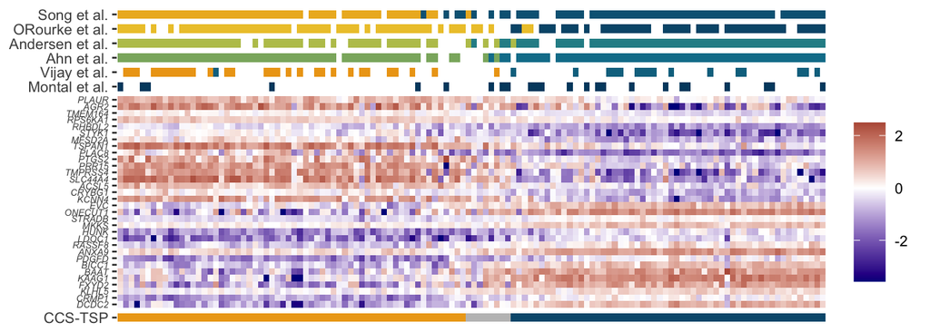

```r
my.plot
```